# Question 4

# Brief discussion

It is hard to quantify quality and profitability from internet rankings, but it does give us an indication of what is popular. To enter the streaming market, audience scores are extremely important.

# Analytics

Movies and tv shows can be split into four quartiles along popularity (represented by the amount of IMDB votes) and quality (the IMDB score). Ideally, a streaming service would want films that are at least in the top quartile for one metric and in the top two quartiles for the other. Older movies and shows are usually cheap to acquire. Combining this with the tier system of the ratings can help management choose films or tv shows that have a higher probability of being successful.

| Title | Quality Quartile | Popularity Quartile | Release Year | Genre |
| --- | --- | --- | --- | --- |
| A Nightmare on Elm Street | 4.00 | 4.00 | 1984.00 | ['horror'] |
| A River Runs Through It | 4.00 | 4.00 | 1992.00 | ['drama'] |
| Any Given Sunday | 3.00 | 4.00 | 1999.00 | ['drama', 'sport'] |
| Awakenings | 4.00 | 4.00 | 1990.00 | ['drama', 'european'] |
| Blade | 4.00 | 4.00 | 1998.00 | ['action', 'scifi', 'horror'] |
| Bombay | 4.00 | 3.00 | 1995.00 | ['romance', 'drama'] |
| Bonnie and Clyde | 4.00 | 4.00 | 1967.00 | ['drama', 'crime', 'action'] |
| Christine | 3.00 | 4.00 | 1983.00 | ['horror', 'thriller', 'european'] |
| Cliffhanger | 3.00 | 4.00 | 1993.00 | ['thriller', 'action', 'animation'] |
| Desperado | 4.00 | 4.00 | 1995.00 | ['thriller', 'action', 'crime', 'western', 'european'] |
| Dil Se.. | 4.00 | 3.00 | 1998.00 | ['drama', 'romance'] |
| Dirty Harry | 4.00 | 4.00 | 1971.00 | ['thriller', 'crime', 'action'] |
| Donnie Brasco | 4.00 | 4.00 | 1997.00 | ['thriller', 'drama', 'crime'] |
| Eddie Murphy Raw | 4.00 | 3.00 | 1987.00 | ['comedy', 'documentation'] |
| Forrest Gump | 4.00 | 4.00 | 1994.00 | ['drama', 'romance', 'comedy'] |
| Full Metal Jacket | 4.00 | 4.00 | 1987.00 | ['drama', 'war'] |
| Gattaca | 4.00 | 4.00 | 1997.00 | ['thriller', 'drama', 'scifi'] |
| Girl, Interrupted | 4.00 | 4.00 | 1999.00 | ['drama', 'european'] |
| Happy Gilmore | 3.00 | 4.00 | 1996.00 | ['comedy', 'sport'] |
| Hum Aapke Hain Koun..! | 4.00 | 3.00 | 1994.00 | ['romance', 'comedy', 'drama'] |
| In the Line of Fire | 4.00 | 4.00 | 1993.00 | ['drama', 'thriller', 'action', 'crime'] |
| Kabhi Haan Kabhi Naa | 4.00 | 3.00 | 1994.00 | ['comedy', 'drama', 'music', 'romance'] |
| Kuch Kuch Hota Hai | 4.00 | 3.00 | 1998.00 | ['drama', 'romance', 'comedy'] |
| Last Action Hero | 3.00 | 4.00 | 1993.00 | ['comedy', 'action', 'fantasy'] |
| Life of Brian | 4.00 | 4.00 | 1979.00 | ['comedy'] |
| Little Women | 4.00 | 4.00 | 1994.00 | ['drama', 'family', 'romance'] |
| Lupin the Third: The Castle of Cagliostro | 4.00 | 3.00 | 1979.00 | ['comedy', 'animation', 'action', 'fantasy', 'family'] |
| Menace II Society | 4.00 | 3.00 | 1993.00 | ['drama', 'crime', 'thriller'] |
| Monty Python Live at the Hollywood Bowl | 4.00 | 3.00 | 1982.00 | ['comedy', 'documentation'] |
| Monty Python and the Holy Grail | 4.00 | 4.00 | 1975.00 | ['comedy', 'fantasy'] |
| My Fair Lady | 4.00 | 4.00 | 1964.00 | ['drama', 'music', 'romance', 'family'] |
| My Girl | 3.00 | 4.00 | 1991.00 | ['comedy', 'drama', 'family', 'romance', 'european'] |
| Neon Genesis Evangelion: The End of Evangelion | 4.00 | 3.00 | 1997.00 | ['scifi', 'action', 'drama', 'fantasy', 'animation'] |
| Once Upon a Time in America | 4.00 | 4.00 | 1984.00 | ['drama', 'crime', 'european'] |
| Pet Sematary | 3.00 | 4.00 | 1989.00 | ['horror', 'fantasy', 'thriller'] |
| Road Trip | 3.00 | 4.00 | 2000.00 | ['comedy'] |
| Saving Private Ryan | 4.00 | 4.00 | 1998.00 | ['drama', 'war'] |
| Seven Years in Tibet | 4.00 | 4.00 | 1997.00 | ['drama', 'history', 'war'] |
| Stand by Me | 4.00 | 4.00 | 1986.00 | ['drama'] |
| Starship Troopers | 4.00 | 4.00 | 1997.00 | ['scifi', 'thriller', 'action'] |
| Taxi Driver | 4.00 | 4.00 | 1976.00 | ['crime', 'drama'] |
| Teenage Mutant Ninja Turtles | 3.00 | 4.00 | 1990.00 | ['scifi', 'action', 'comedy', 'family'] |
| The Devil's Advocate | 4.00 | 4.00 | 1997.00 | ['horror', 'thriller', 'drama'] |
| The Exorcist | 4.00 | 4.00 | 1973.00 | ['horror'] |
| The General's Daughter | 3.00 | 4.00 | 1999.00 | ['drama', 'crime', 'thriller'] |
| The Guns of Navarone | 4.00 | 3.00 | 1961.00 | ['war', 'action', 'drama'] |
| The Mask of Zorro | 3.00 | 4.00 | 1998.00 | ['action', 'thriller', 'western', 'comedy', 'romance'] |
| The Patriot | 4.00 | 4.00 | 2000.00 | ['drama', 'action', 'history', 'war'] |
| The Professionals | 4.00 | 3.00 | 1966.00 | ['western', 'action', 'european'] |
| The Quick and the Dead | 3.00 | 4.00 | 1995.00 | ['western', 'thriller', 'action', 'romance'] |
| The Replacements | 3.00 | 4.00 | 2000.00 | ['comedy', 'sport'] |
| Top Gun | 3.00 | 4.00 | 1986.00 | ['drama', 'action'] |
| U.S. Marshals | 3.00 | 4.00 | 1998.00 | ['thriller', 'crime', 'action'] |
| When Harry Met Sally... | 4.00 | 4.00 | 1989.00 | ['romance', 'comedy', 'drama'] |
| White Christmas | 4.00 | 3.00 | 1954.00 | ['romance', 'comedy', 'music'] |
| Wild Things | 3.00 | 4.00 | 1998.00 | ['drama', 'thriller', 'crime', 'european'] |
| You've Got Mail | 3.00 | 4.00 | 1998.00 | ['romance', 'drama', 'comedy'] |

Thus a list has been compiled of possible films that can be good contenders to be acquired as a back catalogue for starting up a streaming service. Obviously newer films and tv shows are also required. To avoid overspending, it is useful to consider what genres are currently popular and would be a good addition to a hypothetical streaming service.

Based on this graph, drama movies are the most popular and the company should invest in new drama movies for the streaming platform.

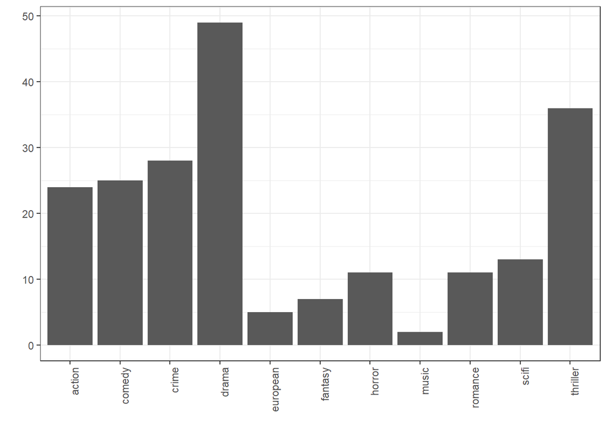

And lastly, it is worth considering the popularity of different age ratings of tv shows over time, as it is important to consider when shows are decided on.

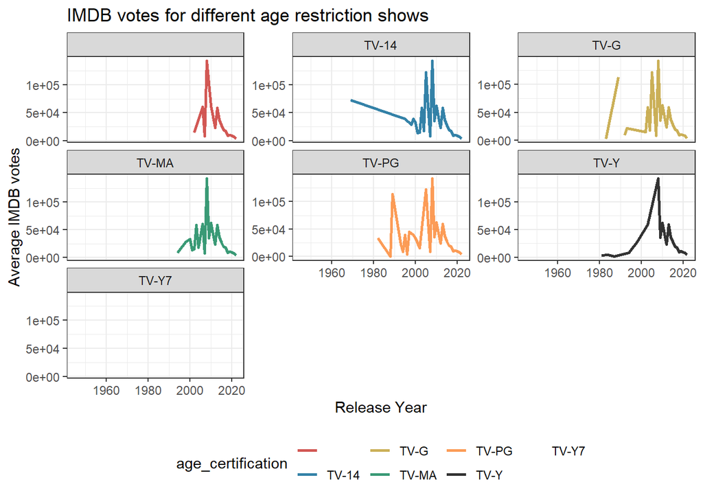